# Practical Machine Learning Project

rcritika

February 28, 2018

## Executive Summary

In this project we have to pedict model and analyse the data which is drawn from devices such as Jawbone Up, Nike FuelBand, and Fitbit. It is now possible to collect a large amount of data about personal activity relatively inexpensively. These type of devices are part of the quantified self movement - a group of enthusiasts who take measurements about themselves regularly to improve their health, to find patterns in their behavior, or because they are tech geeks. One thing that people regularly do is quantify how much of a particular activity they do, but they rarely quantify how well they do it. Therefore in this project, the goal will be to use data from accelerometers on the belt, forearm, arm, and dumbell of 6 participants. They were asked to perform barbell lifts correctly and incorrectly in 5 different ways.

Six young healthy participants were asked to perform one set of 10 repetitions of the Unilateral Dumbbell Biceps Curl in five different fashions: * Class A - exactly according to the specification * Class B - throwing the elbows to the front * Class C - lifting the dumbbell only halfway * Class D - lowering the dumbbell only halfway * Class E - throwing the hips to the front

## Processing Data

The training data for this project are available here:

https://d396qusza40orc.cloudfront.net/predmachlearn/pml-training.csv

The test data are available here:

https://d396qusza40orc.cloudfront.net/predmachlearn/pml-testing.csv

Load required R libraries and set the global option:

```r
library(caret)
```

```r
library(rpart)
library(lattice)
library(ggplot2)
```

Download the training and test data sets:

```r
Trainurl <- "https://d396qusza40orc.cloudfront.net/predmachlearn/pml-training.csv"
download.file(Trainurl, "training.csv")
Testurl <- "https://d396qusza40orc.cloudfront.net/predmachlearn/pml-testing.csv"
download.file(Testurl, "testing.csv")
training <- read.csv("training.csv", header = TRUE, na.strings = c("NA",""))
testing <- read.csv("testing.csv", header = TRUE, na.strings = c("NA",""))
```

The training set consists of 19622 observations of 160 variables, one of which is the dependent variable as far as this study is concerned:

```r
dim(training)
```

```
## [1] 19622   160
```

Columns in the orignal training and testing datasets that are mostly filled with missing values are then removed. This will help to remove unnecessary predictors from dataset

To do this, count the number of missing values in each column of the full training dataset. We use those sums to identify the columns which are not required as predictors.

```r
training_filter_col <- training[,colSums(is.na(training))==0]
testing_filter_col <- testing[,colSums(is.na(testing))==0]
```

Deleting the additional columns from the data sets which are not required like “X”, “user_name”, “raw_timestamp_part_1”, “raw_timestamp_part_2”, “cvtd_timestamp”, “new_window”, “num_window”.

```r
remove_col <- c("X", "user_name", "raw_timestamp_part_1", "raw_timestamp_part_2", "cvtd_timestamp", "new_window", "num_window")
training_filter_col <- training_filter_col[,!names(training_filter_col) %in% remove_col]
testing_filter_col <- testing_filter_col[,!names(testing_filter_col) %in% remove_col]
```

## Modelling Data

### Slicing the Data

The training data is divided into two sets. This first is a training set with 70% of the data which is used to train the model. The second is a validation set used to assess model performance.

```r
in.training <- createDataPartition(training_filter_col$classe, p=0.70, list=FALSE)
trainPCA <- training_filter_col[in.training,]
ValidDataPCA <- training_filter_col[-in.training,]
trainPCA <- trainPCA[complete.cases(trainPCA),]
ValidDataPCA <- ValidDataPCA[complete.cases(ValidDataPCA),]
```

```r
library("randomForest")
set.seed(32233)
randomForMod <- randomForest(classe~., data=trainPCA, importance=TRUE)
randomForMod
```

```
##
## Call:
##  randomForest(formula = classe ~ ., data = trainPCA, importance = TRUE)
##                Type of random forest: classification
##                      Number of trees: 500
## No. of variables tried at each split: 7
##
##         OOB estimate of  error rate: 0.47%
## Confusion matrix:
##      A    B    C    D    E  class.error
## A 3904    1    0    0    1 0.0005120328
## B   12 2641    5    0    0 0.0063957863
## C    0   14 2380    2    0 0.0066777963
## D    1    0   21 2228    2 0.0106571936
## E    0    0    1    5 2519 0.0023762376
```

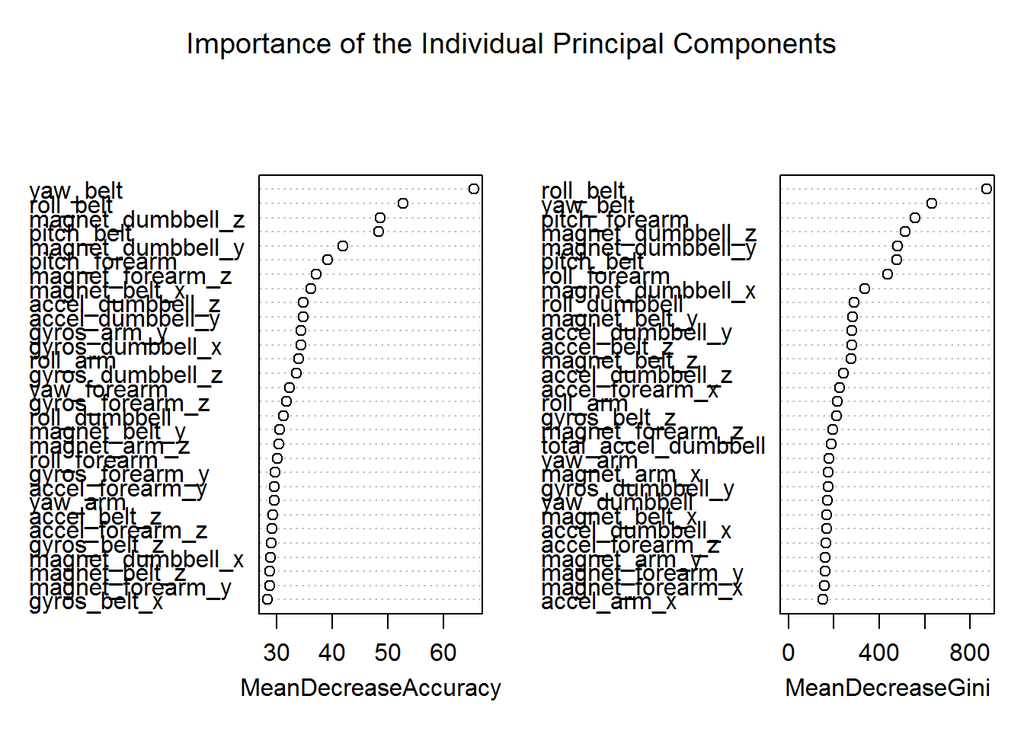

```r
varImpPlot(randomForMod, sort=TRUE, main="Importance of the Individual Principal Components")
```

### Out-of-Sample Error Estimate

Call the ‘predict’ function again so that our trained model can be applied to our validation test dataset. We can then view the resulting table in the ‘confusionMatrix’ function’s output to see how well the model predicted/classified the values in the validation test set

```r
predValidRF <- predict(randomForMod,ValidDataPCA)
confusionMatrix(ValidDataPCA$classe, predValidRF)
```

```
## Confusion Matrix and Statistics
##
##           Reference
## Prediction    A    B    C    D    E
##          A 1673    1    0    0    0
##          B    5 1133    1    0    0
##          C    0    4 1021    1    0
##          D    0    0    9  953    2
##          E    0    0    3    3 1076
##
## Overall Statistics
##
##                Accuracy : 0.9951
##                  95% CI : (0.9929, 0.9967)
##     No Information Rate : 0.2851
##     P-Value [Acc > NIR] : < 2.2e-16
##
##                   Kappa : 0.9938
##  Mcnemar's Test P-Value : NA
##
## Statistics by Class:
##
##                      Class: A Class: B Class: C Class: D Class: E
## Sensitivity            0.9970   0.9956   0.9874   0.9958   0.9981
## Specificity            0.9998   0.9987   0.9990   0.9978   0.9988
## Pos Pred Value         0.9994   0.9947   0.9951   0.9886   0.9945
## Neg Pred Value         0.9988   0.9989   0.9973   0.9992   0.9996
## Prevalence             0.2851   0.1934   0.1757   0.1626   0.1832
## Detection Rate         0.2843   0.1925   0.1735   0.1619   0.1828
## Detection Prevalence   0.2845   0.1935   0.1743   0.1638   0.1839
## Balanced Accuracy      0.9984   0.9972   0.9932   0.9968   0.9984
```

The estimated out-of-sample error is 1.000 minus the model’s accuracy, the later of which is provided in the output of the confusionmatrix, or more directly via the ‘postresample’ function.

```r
accur <- postResample(ValidDataPCA$classe, predValidRF)
modAccuracy <- accur[[1]]
modAccuracy
```

```
## [1] 0.9950722
```

```r
out_of_sample_error <- 1 - modAccuracy
out_of_sample_error
```

```
## [1] 0.004927782
```

## Predicted Result

Finally, we apply the pre-processing to the original testing dataset. We then run our model against the testing dataset and display the predicted results.

```r
testPC <- predict(randomForMod, testing_filter_col)
testPC
```

```
##  1  2  3  4  5  6  7  8  9 10 11 12 13 14 15 16 17 18 19 20
##  B  A  B  A  A  E  D  B  A  A  B  C  B  A  E  E  A  B  B  B
## Levels: A B C D E
```